# Data Analysis for the Prosody Project

Lily Zihui Zhu

12/31/2021

## Overview

This document contains all R code used for statistical analysis and to generate visualizations for the Prosody Project. There are 4 phonetic features of interest, namely wh-word $\Delta$ F0, wh-word duration, vowel $\Delta$ F0, vowel duration. The analysis includes:

1. Comparing the three-types of wh-questions (EQs/PQs/FQs)
   - A linear mixed effect model with the formula: Phonetic feature ∼ Question type + (1|Participant ID) + (1|Context ID).
   - Visualizations with pitch contour and duration point and line plots for both wh-words and vowel
2. Comparing wh-word positions (mid/end) and wh-in-situ questions (EQs/PQs)
   - A linear mixed effect model with the formula: Phonetic feature ∼ Question type * wh-word position + (1|Participant ID) + (1|Context ID)
   - Visualizations with pitch contour and duration point and line plots for both wh-words and vowels with sentence-medial/final wh-words

### 0.0 Load all necessary packages

Including (may contain overlaps):

report, parameters, dplyr, ggplot2, lsr, lme4, afex, multcomp, emmeans, cowplot, ggpubr, lmerTest, egg.

### 0.1 Read in source file

```r
# load data
data = read.csv("x19_NA_whword_vowel_f0_duration_data.csv", header = TRUE)

# inspect it
# View(data)
```

## Part 1. EQs vs. PQs vs. FQs

### 1.1 Filter out the fillers

Keep only the three question types of interest.

```r
Q3 = (data %>% filter(q_type != "filler"))

# inspect it
# View(Q3)
```

### 1.2 Generate summary statistics

Calculate means and sd’s for each question type

```r
# calculate means by question type
Q3 %>%
  group_by(q_type) %>%
  summarize(mean(wh_delta_pitch), mean(vowel_delta_pitch), mean(wh_duration), mean(vowel_duration))
```

```
## # A tibble: 3 x 5
##   q_type `mean(wh_delta_p~ `mean(vowel_delta~ `mean(wh_durati~ `mean(vowel_dura~
##   <chr>              <dbl>              <dbl>            <dbl>             <dbl>
## 1 EQ                 79.7               49.3             0.331            0.138
## 2 FQ                  7.73               7.65            0.217            0.0783
## 3 PQ                 16.8                1.60            0.366            0.152
```

```r
# calculate standard deviations by question type
Q3 %>%
  group_by(q_type) %>%
  summarize(sd(wh_delta_pitch), sd(vowel_delta_pitch), sd(wh_duration), sd(vowel_duration))
```

```
## # A tibble: 3 x 5
##   q_type `sd(wh_delta_pitch)` `sd(vowel_delta~ `sd(wh_duration~ `sd(vowel_durat~
##   <chr>                 <dbl>            <dbl>            <dbl>            <dbl>
## 1 EQ                     80.2             61.2           0.101            0.0790
## 2 FQ                     49.8             34.0           0.0674           0.0501
## 3 PQ                     96.8             66.6           0.120            0.0963
```

### 1.3 Fit data into linear mixed effect models

#### 1.3.1 For wh-word pitch:

```r
# fit the model with participant_ID and stimuli as random effects
wh_pitch_qtype_mixed = lmer(wh_delta_pitch ~ q_type + (1|participant_ID) + (1|stimuli_.), data = Q3)

# see if the random effects are necessary
ranova(wh_pitch_qtype_mixed)
```

```
## ANOVA-like table for random-effects: Single term deletions
##
## Model:
## wh_delta_pitch ~ q_type + (1 | participant_ID) + (1 | stimuli_.)
##                      npar  logLik    AIC    LRT Df Pr(>Chisq)
## <none>                  6 -2797.7 5607.4
## (1 | participant_ID)    5 -2809.2 5628.3 22.886  1  1.719e-06 ***
## (1 | stimuli_.)         5 -2811.5 5633.0 27.553  1  1.528e-07 ***
## ---
## Signif. codes:  0 '***' 0.001 '**' 0.01 '*' 0.05 '.' 0.1 ' ' 1
```

```r
# get slopes coefficients and p-values (not standardized)
# summary(wh_pitch_qtype_mixed)

# generate summary reports based on summary
# as.report_table(report(wh_pitch_qtype_mixed))

# get main effect of question type
anova(wh_pitch_qtype_mixed)
```

```
## Type III Analysis of Variance Table with Satterthwaite's method
##        Sum Sq Mean Sq NumDF  DenDF F value    Pr(>F)
## q_type 504100  252050     2 461.52  49.216 < 2.2e-16 ***
## ---
## Signif. codes:  0 '***' 0.001 '**' 0.01 '*' 0.05 '.' 0.1 ' ' 1
```

```r
# standardize and refit the data for standardized beta
model_parameters(wh_pitch_qtype_mixed, standardize = "refit")
```

```
## # Fixed Effects
##
## Parameter   | Coefficient |   SE |         95% CI | t(484) |      p
## -------------------------------------------------------------------
## (Intercept) |        0.53 | 0.13 | [ 0.27,  0.78] |   4.08 | < .001
## q type [FQ] |       -0.86 | 0.09 | [-1.04, -0.67] |  -9.11 | < .001
## q type [PQ] |       -0.75 | 0.09 | [-0.93, -0.56] |  -7.97 | < .001
##
## # Random Effects
##
## Parameter                      | Coefficient
## --------------------------------------------
## SD (Intercept: participant_ID) |        0.27
## SD (Intercept: stimuli_.)      |        0.27
## SD (Residual)                  |        0.85
```

```r
# get pairwise comparison results
emmeans(wh_pitch_qtype_mixed, pairwise~q_type)
```

```
## $emmeans
##  q_type emmean   SE   df lower.CL upper.CL
##  EQ      79.11 10.9 20.4     56.4    101.8
##  FQ       6.85 10.9 20.5    -15.8     29.6
##  PQ      15.98 10.9 20.4     -6.7     38.7
##
## Degrees-of-freedom method: kenward-roger
## Confidence level used: 0.95
##
## $contrasts
##  contrast estimate   SE  df t.ratio p.value
##  EQ - FQ     72.25 7.93 462   9.107  <.0001
##  EQ - PQ     63.13 7.92 461   7.969  <.0001
##  FQ - PQ     -9.13 7.92 461  -1.152  0.4824
##
## Degrees-of-freedom method: kenward-roger
## P value adjustment: tukey method for comparing a family of 3 estimates
```

```r
# another way to do pairwise comparison after lmer()
# post.hoc.wh_pitch_qtype_mixed <- glht(wh_pitch_qtype_mixed, linfct = mcp(q_type = 'Tukey'))
# summary(post.hoc.wh_pitch_qtype_mixed)
```

#### 1.3.2 For vowel pitch:

```r
# fit the model with participant_ID and stimuli as random effects
vowel_pitch_qtype_mixed = lmer(vowel_delta_pitch ~ q_type + (1|participant_ID) + (1|stimuli_.), data = Q3)

# see if the random effects are necessary
ranova(vowel_pitch_qtype_mixed)
```

```
## ANOVA-like table for random-effects: Single term deletions
##
## Model:
## vowel_delta_pitch ~ q_type + (1 | participant_ID) + (1 | stimuli_.)
##                      npar  logLik    AIC    LRT Df Pr(>Chisq)
## <none>                  6 -2639.0 5290.0
## (1 | participant_ID)    5 -2641.7 5293.4  5.419  1    0.01992 *
## (1 | stimuli_.)         5 -2655.8 5321.5 33.485  1  7.181e-09 ***
## ---
## Signif. codes:  0 '***' 0.001 '**' 0.01 '*' 0.05 '.' 0.1 ' ' 1
```

```r
# get slopes coefficients and p-values (not standardized)
# summary(vowel_pitch_qtype_mixed)

# generate summary reports based on summary
# as.report_table(report(vowel_pitch_qtype_mixed))

# get main effect of question type
anova(vowel_pitch_qtype_mixed)
```

```
## Type III Analysis of Variance Table with Satterthwaite's method
##        Sum Sq Mean Sq NumDF DenDF F value    Pr(>F)
## q_type 214078  107039     2 461.8  39.306 < 2.2e-16 ***
## ---
## Signif. codes:  0 '***' 0.001 '**' 0.01 '*' 0.05 '.' 0.1 ' ' 1
```

```r
# standardize and refit the data for standardized beta
model_parameters(vowel_pitch_qtype_mixed, standardize = "refit")
```

```
## # Fixed Effects
##
## Parameter   | Coefficient |   SE |         95% CI | t(484) |      p
## -------------------------------------------------------------------
## (Intercept) |        0.49 | 0.13 | [ 0.24,  0.74] |   3.80 | < .001
## q type [FQ] |       -0.69 | 0.10 | [-0.88, -0.50] |  -7.12 | < .001
## q type [PQ] |       -0.79 | 0.10 | [-0.98, -0.60] |  -8.14 | < .001
##
## # Random Effects
##
## Parameter                      | Coefficient
## --------------------------------------------
## SD (Intercept: participant_ID) |        0.17
## SD (Intercept: stimuli_.)      |        0.30
## SD (Residual)                  |        0.88
```

```r
# get pairwise comparison results
emmeans(vowel_pitch_qtype_mixed, pairwise~q_type)
```

```
## $emmeans
##  q_type emmean   SE   df lower.CL upper.CL
##  EQ      48.59 7.66 15.2    32.27     64.9
##  FQ       7.38 7.67 15.2    -8.94     23.7
##  PQ       1.59 7.66 15.2   -14.72     17.9
##
## Degrees-of-freedom method: kenward-roger
## Confidence level used: 0.95
##
## $contrasts
##  contrast estimate   SE  df t.ratio p.value
##  EQ - FQ     41.21 5.78 462   7.123  <.0001
##  EQ - PQ     47.00 5.78 462   8.137  <.0001
##  FQ - PQ      5.79 5.77 461   1.003  0.5751
##
## Degrees-of-freedom method: kenward-roger
## P value adjustment: tukey method for comparing a family of 3 estimates
```

```r
# another way to do pairwise comparison after lmer()
# post.hoc.vowel_pitch_qtype_mixed <- glht(vowel_pitch_qtype_mixed, linfct = mcp(q_type = 'Tukey'))
# summary(post.hoc.vowel_pitch_qtype_mixed)
```

#### 1.3.3 For wh-word duration:

```r
# fit the model with participant_ID and stimuli as random effects
wh_duration_qtype_mixed = lmer(wh_duration ~ q_type + (1|participant_ID) + (1|stimuli_.), data = Q3)

# see if the random effects are necessary
ranova(wh_duration_qtype_mixed)
```

```
## ANOVA-like table for random-effects: Single term deletions
##
## Model:
## wh_duration ~ q_type + (1 | participant_ID) + (1 | stimuli_.)
##                      npar logLik      AIC     LRT Df Pr(>Chisq)
## <none>                  6 515.14 -1018.28
## (1 | participant_ID)    5 464.95  -919.90 100.377  1  < 2.2e-16 ***
## (1 | stimuli_.)         5 467.32  -924.63  95.644  1  < 2.2e-16 ***
## ---
## Signif. codes:  0 '***' 0.001 '**' 0.01 '*' 0.05 '.' 0.1 ' ' 1
```

```r
# get slopes coefficients and p-values (not standardized)
# summary(wh_duration_qtype_mixed)

# generate summary reports based on summary
# as.report_table(report(wh_duration_qtype_mixed))

# get main effect of question type
anova(wh_duration_qtype_mixed)
```

```
## Type III Analysis of Variance Table with Satterthwaite's method
##        Sum Sq Mean Sq NumDF  DenDF F value    Pr(>F)
## q_type 1.9763 0.98814     2 461.29   164.9 < 2.2e-16 ***
## ---
## Signif. codes:  0 '***' 0.001 '**' 0.01 '*' 0.05 '.' 0.1 ' ' 1
```

```r
# standardize and refit the data for standardized beta
model_parameters(wh_duration_qtype_mixed, standardize = "refit")
```

```
## # Fixed Effects
##
## Parameter   | Coefficient |   SE |         95% CI | t(484) |      p
## -------------------------------------------------------------------
## (Intercept) |        0.23 | 0.16 | [-0.08,  0.55] |   1.46 | 0.146
## q type [FQ] |       -0.99 | 0.07 | [-1.13, -0.84] | -13.47 | < .001
## q type [PQ] |        0.28 | 0.07 | [ 0.13,  0.42] |   3.79 | < .001
##
## # Random Effects
##
## Parameter                      | Coefficient
## --------------------------------------------
## SD (Intercept: participant_ID) |        0.39
## SD (Intercept: stimuli_.)      |        0.37
## SD (Residual)                  |        0.66
```

```r
# get pairwise comparison results
emmeans(wh_duration_qtype_mixed, pairwise~q_type)
```

```
## $emmeans
##  q_type emmean     SE   df lower.CL upper.CL
##  EQ      0.332 0.0188 18.4    0.293    0.372
##  FQ      0.217 0.0188 18.4    0.177    0.256
##  PQ      0.365 0.0188 18.4    0.325    0.404
##
## Degrees-of-freedom method: kenward-roger
## Confidence level used: 0.95
##
## $contrasts
##  contrast estimate      SE  df t.ratio p.value
##  EQ - FQ    0.1156 0.00858 461  13.466  <.0001
##  EQ - PQ   -0.0325 0.00857 461  -3.794  0.0005
##  FQ - PQ   -0.1481 0.00857 461 -17.288  <.0001
##
## Degrees-of-freedom method: kenward-roger
## P value adjustment: tukey method for comparing a family of 3 estimates
```

```r
# another way to do pairwise comparison after lmer()
# post.hoc.wh_duration_qtype_mixed <- glht(wh_duration_qtype_mixed, linfct = mcp(q_type = 'Tukey'))
# summary(post.hoc.wh_duration_qtype_mixed)
```

#### 1.3.4 For vowel duration:

```r
# fit the model with participant_ID and stimuli as random effects
vowel_duration_qtype_mixed = lmer(vowel_duration ~ q_type + (1|participant_ID) + (1|stimuli_.), data = Q3)

# see if the random effects are necessary
ranova(vowel_duration_qtype_mixed)
```

```
## ANOVA-like table for random-effects: Single term deletions
##
## Model:
## vowel_duration ~ q_type + (1 | participant_ID) + (1 | stimuli_.)
##                      npar logLik     AIC    LRT Df Pr(>Chisq)
## <none>                  6 739.82 -1467.7
## (1 | participant_ID)    5 722.43 -1434.8  34.80  1  3.663e-09 ***
## (1 | stimuli_.)         5 548.85 -1087.7 381.95  1  < 2.2e-16 ***
## ---
## Signif. codes:  0 '***' 0.001 '**' 0.01 '*' 0.05 '.' 0.1 ' ' 1
```

```r
# get slopes coefficients and p-values (not standardized)
# summary(vowel_duration_qtype_mixed)

# generate summary reports based on summary
# as.report_table(report(vowel_duration_qtype_mixed))

# get main effect of question type
anova(vowel_duration_qtype_mixed)
```

```
## Type III Analysis of Variance Table with Satterthwaite's method
##         Sum Sq Mean Sq NumDF  DenDF F value    Pr(>F)
## q_type 0.52129 0.26064     2 461.43  109.13 < 2.2e-16 ***
## ---
## Signif. codes:  0 '***' 0.001 '**' 0.01 '*' 0.05 '.' 0.1 ' ' 1
```

```r
# standardize and refit the data for standardized beta
model_parameters(vowel_duration_qtype_mixed, standardize = "refit")
```

```
## # Fixed Effects
##
## Parameter   | Coefficient |   SE |         95% CI | t(484) |      p
## -------------------------------------------------------------------
## (Intercept) |        0.18 | 0.25 | [-0.31,  0.67] |   0.72 | 0.472
## q type [FQ] |       -0.72 | 0.06 | [-0.85, -0.60] | -11.20 | < .001
## q type [PQ] |        0.18 | 0.06 | [ 0.05,  0.30] |   2.73 | 0.007
##
## # Random Effects
##
## Parameter                      | Coefficient
## --------------------------------------------
## SD (Intercept: participant_ID) |        0.22
## SD (Intercept: stimuli_.)      |        0.72
## SD (Residual)                  |        0.58
```

```r
# get pairwise comparison results
emmeans(vowel_duration_qtype_mixed, pairwise~q_type)
```

```
## $emmeans
##  q_type emmean    SE   df lower.CL upper.CL
##  EQ     0.1379 0.021 9.09   0.0905    0.185
##  FQ     0.0772 0.021 9.10   0.0298    0.125
##  PQ     0.1526 0.021 9.09   0.1052    0.200
##
## Degrees-of-freedom method: kenward-roger
## Confidence level used: 0.95
##
## $contrasts
##  contrast estimate      SE  df t.ratio p.value
##  EQ - FQ    0.0607 0.00542 461  11.198  <.0001
##  EQ - PQ   -0.0147 0.00541 461  -2.726  0.0182
##  FQ - PQ   -0.0754 0.00541 461 -13.947  <.0001
##
## Degrees-of-freedom method: kenward-roger
## P value adjustment: tukey method for comparing a family of 3 estimates
```

```r
# another way to do pairwise comparison after lmer()
# post.hoc.vowel_duration_qtype_mixed <- glht(vowel_duration_qtype_mixed, linfct = mcp(q_type = 'Tukey'))
# summary(post.hoc.vowel_duration_qtype_mixed)
```

### 1.4 Make pitch contour and duration plots

#### 1.4.1 For wh-word:

```r
# get dataframe: "time 0 - start pitch", "time duration - end pitch"
wh_pitch_start_end = rbind(Q3 %>% group_by(q_type) %>% summarise(time = 0, pitch = mean(wh_start_pitch)), Q3 %>% group_by(q_type) %>% summarise(time = mean(wh_duration), pitch = mean(wh_end_pitch)))

wh_pitch_start_end
```

```
## # A tibble: 6 x 3
##   q_type  time pitch
##   <chr>  <dbl> <dbl>
## 1 EQ     0      156.
## 2 FQ     0      200.
## 3 PQ     0      169.
## 4 EQ     0.331  235.
## 5 FQ     0.217  208.
## 6 PQ     0.366  186.
```

```r
# make the point and line graph
wh_qtype_graph = ggplot(data = wh_pitch_start_end, mapping = aes(x = time, y = pitch,
      group = q_type, color = q_type, shape = q_type)) +
  geom_point(stat = "summary", fun = mean, position = "dodge")+
  geom_line(stat='summary', fun='mean') +
  ylab("F0(Hz)") + ylim(150,240) +
  xlab("T(s)")+ xlim(0.0,0.4) +
  labs(color = "Type",shape = "Type")
```

#### 1.4.2 For vowel:

```r
# get dataframe: "time 0 - start pitch", "time duration - end pitch"
vowel_pitch_start_end = rbind(Q3 %>% group_by(q_type) %>% summarise(time = 0, pitch = mean(vowel_start_pitch)), Q3 %>% group_by(q_type) %>% summarise(time = mean(vowel_duration), pitch = mean(vowel_end_pitch)))

vowel_pitch_start_end
```

```
## # A tibble: 6 x 3
##   q_type   time pitch
##   <chr>   <dbl> <dbl>
## 1 EQ     0       161.
## 2 FQ     0       195.
## 3 PQ     0       177.
## 4 EQ     0.138   210.
## 5 FQ     0.0783  203.
## 6 PQ     0.152   179.
```

```r
# make the point and line graph
vowel_qtype_graph = ggplot(data = vowel_pitch_start_end, mapping = aes(x = time, y = pitch,
                            group = q_type, color = q_type, shape = q_type)) +
  geom_point(stat = "summary", fun = mean, position = "dodge")+
  geom_line(stat='summary', fun='mean') +
  ylab("F0(Hz)") + ylim(150,240) +
  xlab("T(s)")+ xlim(0.0,0.4) +
  labs(color = "Type",shape = "Type")
```

#### 1.4.3 Put the two graphs side-by-side:

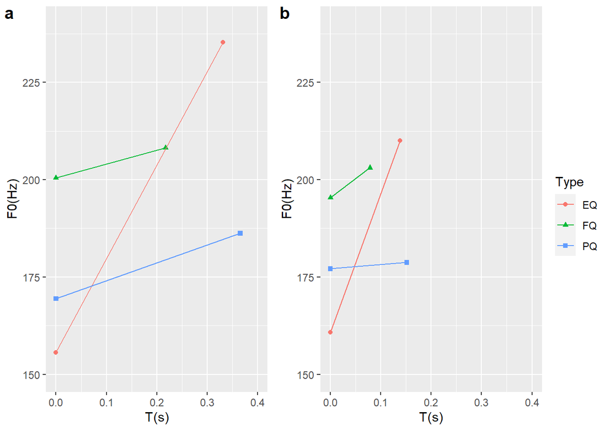

```r
# combine the two graphs on one line with common legend and labels
qtype_graph = ggpubr::ggarrange(wh_qtype_graph, vowel_qtype_graph, common.legend = TRUE,
                        legend = "right", labels = "auto")

# save the graph
# ggsave("qtype_graph_1x2.png", plot = qtype_graph, device = "png", scale = 5)

qtype_graph
```

## Part 2. EQs/PQs vs. mid/end

### 2.1 Filter out FQs

```r
# only keep EQs and PQs
EQ_PQ = data %>% filter(q_type %in% c("EQ", "PQ"))

# inspect it
# View (EQ_PQ)
```

### 2.2 Generate summary statistics

```r
# get mean by question type
EQ_PQ %>%
  group_by(q_type) %>%
  summarize(mean(wh_delta_pitch), mean(vowel_delta_pitch), mean(wh_duration), mean(vowel_duration))
```

```
## # A tibble: 2 x 5
##   q_type `mean(wh_delta_p~ `mean(vowel_delta~ `mean(wh_durati~ `mean(vowel_dura~
##   <chr>              <dbl>              <dbl>            <dbl>             <dbl>
## 1 EQ                  79.7              49.3             0.331             0.138
## 2 PQ                  16.8               1.60            0.366             0.152
```

```r
# get mean by wh-word position
EQ_PQ %>%
  group_by(wh_position) %>%
  summarize(mean(wh_delta_pitch), mean(vowel_delta_pitch), mean(wh_duration), mean(vowel_duration))
```

```
## # A tibble: 2 x 5
##   wh_position `mean(wh_delta_pitch)` `mean(vowel_delta_pitch)` `mean(wh_duratio~
##   <chr>                        <dbl>                     <dbl>             <dbl>
## 1 end                           78.4                      45.9             0.397
## 2 mid                           33.0                      15.1             0.324
## # ... with 1 more variable: mean(vowel_duration) <dbl>
```

```r
# get mean grouped by both question type and wh-word position
EQ_PQ %>%
  group_by(wh_position, q_type) %>%
  summarize(mean(wh_delta_pitch), mean(vowel_delta_pitch), mean(wh_duration), mean(vowel_duration))
```

```
## # A tibble: 4 x 6
## # Groups:   wh_position [2]
##   wh_position q_type `mean(wh_delta_pitch)` `mean(vowel_delta_~ `mean(wh_durati~
##   <chr>       <chr>                   <dbl>               <dbl>            <dbl>
## 1 end         EQ                     118.                 77.5             0.377
## 2 end         PQ                      38.4                13.7             0.419
## 3 mid         EQ                      60.3                34.9             0.308
## 4 mid         PQ                       6.23               -4.33            0.340
## # ... with 1 more variable: mean(vowel_duration) <dbl>
```

### 2.3 Fit data into linear mixed effect models

Question type and wh-word position are both entered fixed effects.

#### 2.3.1 For wh-word pitch:

```r
# fit the model with participant_ID and stimuli as random effects
wh_pitch_inter_mixed =lmer(wh_delta_pitch ~ q_type*wh_position + (1|participant_ID) + (1|stimuli_.), data = EQ_PQ)

# see if the random effects are necessary
ranova(wh_pitch_inter_mixed)
```

```
## ANOVA-like table for random-effects: Single term deletions
##
## Model:
## wh_delta_pitch ~ q_type + wh_position + (1 | participant_ID) + (1 | stimuli_.) + q_type:wh_position
##                      npar  logLik    AIC    LRT Df Pr(>Chisq)
## <none>                  7 -1894.6 3803.3
## (1 | participant_ID)    6 -1901.4 3814.8 13.523  1  0.0002356 ***
## (1 | stimuli_.)         6 -1901.9 3815.9 14.597  1  0.0001331 ***
## ---
## Signif. codes:  0 '***' 0.001 '**' 0.01 '*' 0.05 '.' 0.1 ' ' 1
```

```r
# get slopes coefficients and p-values (not standardized)
# summary(wh_pitch_inter_mixed)

# generate summary reports based on summary
# as.report_table(report(wh_pitch_inter_mixed))

# standardize and refit the data for standardized beta
model_parameters(wh_pitch_inter_mixed, standardize = "refit")
```

```
## # Fixed Effects
##
## Parameter                       | Coefficient |   SE |         95% CI | t(320) |      p
## ---------------------------------------------------------------------------------------
## (Intercept)                     |        0.74 | 0.21 | [ 0.33,  1.14] |   3.58 | < .001
## q type [PQ]                     |       -0.86 | 0.16 | [-1.17, -0.54] |  -5.30 | < .001
## wh position [mid]               |       -0.62 | 0.24 | [-1.09, -0.15] |  -2.58 | 0.010
## q type [PQ] * wh position [mid] |        0.28 | 0.20 | [-0.11,  0.67] |   1.43 | 0.155
##
## # Random Effects
##
## Parameter                      | Coefficient
## --------------------------------------------
## SD (Intercept: participant_ID) |        0.28
## SD (Intercept: stimuli_.)      |        0.28
## SD (Residual)                  |        0.84
```

#### 2.3.2 For vowel pitch:

```r
# fit the model with participant_ID and stimuli as random effects
vowel_pitch_inter_mixed =lmer(vowel_delta_pitch ~ q_type*wh_position + (1|participant_ID) + (1|stimuli_.), data = EQ_PQ)

# see if the random effects are necessary
ranova(vowel_pitch_inter_mixed)
```

```
## ANOVA-like table for random-effects: Single term deletions
##
## Model:
## vowel_delta_pitch ~ q_type + wh_position + (1 | participant_ID) + (1 | stimuli_.) + q_type:wh_position
##                      npar  logLik    AIC     LRT Df Pr(>Chisq)
## <none>                  7 -1789.3 3592.6
## (1 | participant_ID)    6 -1791.3 3594.7  4.0771  1    0.04347 *
## (1 | stimuli_.)         6 -1800.3 3612.6 22.0406  1   2.67e-06 ***
## ---
## Signif. codes:  0 '***' 0.001 '**' 0.01 '*' 0.05 '.' 0.1 ' ' 1
```

```r
# get slopes coefficients and p-values (not standardized)
# summary(vowel_pitch_inter_mixed)

# generate summary reports based on summary
# as.report_table(report(vowel_pitch_inter_mixed))

# standardize and refit the data for standardized beta
model_parameters(vowel_pitch_inter_mixed, standardize = "refit")
```

```
## # Fixed Effects
##
## Parameter                       | Coefficient |   SE |         95% CI | t(320) |      p
## ---------------------------------------------------------------------------------------
## (Intercept)                     |        0.75 | 0.22 | [ 0.31,  1.19] |   3.36 | < .001
## q type [PQ]                     |       -0.92 | 0.16 | [-1.24, -0.60] |  -5.66 | < .001
## wh position [mid]               |       -0.62 | 0.27 | [-1.15, -0.09] |  -2.31 | 0.022
## q type [PQ] * wh position [mid] |        0.35 | 0.20 | [-0.04,  0.74] |   1.77 | 0.077
##
## # Random Effects
##
## Parameter                      | Coefficient
## --------------------------------------------
## SD (Intercept: participant_ID) |        0.19
## SD (Intercept: stimuli_.)      |        0.32
## SD (Residual)                  |        0.85
```

#### 2.3.3 For wh-word duration:

```r
# fit the model with participant_ID and stimuli as random effects
wh_duration_inter_mixed =lmer(wh_duration ~ q_type*wh_position + (1|participant_ID) + (1|stimuli_.), data = EQ_PQ)

# see if the random effects are necessary
ranova(wh_duration_inter_mixed)
```

```
## ANOVA-like table for random-effects: Single term deletions
##
## Model:
## wh_duration ~ q_type + wh_position + (1 | participant_ID) + (1 | stimuli_.) + q_type:wh_position
##                      npar logLik     AIC    LRT Df Pr(>Chisq)
## <none>                  7 314.73 -615.46
## (1 | participant_ID)    6 275.05 -538.10 79.358  1  < 2.2e-16 ***
## (1 | stimuli_.)         6 290.29 -568.58 48.878  1  2.723e-12 ***
## ---
## Signif. codes:  0 '***' 0.001 '**' 0.01 '*' 0.05 '.' 0.1 ' ' 1
```

```r
# get slopes coefficients and p-values (not standardized)
# summary(wh_duration_inter_mixed)

# generate summary reports based on summary
# as.report_table(report(wh_duration_inter_mixed))

# standardize and refit the data for standardized beta
model_parameters(wh_duration_inter_mixed, standardize = "refit")
```

```
## # Fixed Effects
##
## Parameter                       | Coefficient |   SE |         95% CI | t(320) |     p
## --------------------------------------------------------------------------------------
## (Intercept)                     |        0.25 | 0.27 | [-0.28,  0.79] |   0.93 | 0.353
## q type [PQ]                     |        0.36 | 0.14 | [ 0.08,  0.63] |   2.56 | 0.011
## wh position [mid]               |       -0.60 | 0.30 | [-1.19,  0.00] |  -1.97 | 0.050
## q type [PQ] * wh position [mid] |       -0.11 | 0.17 | [-0.44,  0.23] |  -0.62 | 0.534
##
## # Random Effects
##
## Parameter                      | Coefficient
## --------------------------------------------
## SD (Intercept: participant_ID) |        0.49
## SD (Intercept: stimuli_.)      |        0.39
## SD (Residual)                  |        0.73
```

#### 2.3.4 For vowel duration:

```r
# fit the model with participant_ID and stimuli as random effects
vowel_duration_inter_mixed =lmer(vowel_duration ~ q_type*wh_position + (1|participant_ID) + (1|stimuli_.), data = EQ_PQ)

# see if the random effects are necessary
ranova(vowel_duration_inter_mixed)
```

```
## ANOVA-like table for random-effects: Single term deletions
##
## Model:
## vowel_duration ~ q_type + wh_position + (1 | participant_ID) + (1 | stimuli_.) + q_type:wh_position
##                      npar logLik     AIC     LRT Df Pr(>Chisq)
## <none>                  7 469.08 -924.15
## (1 | participant_ID)    6 457.76 -903.52  22.633  1  1.961e-06 ***
## (1 | stimuli_.)         6 322.95 -633.90 292.257  1  < 2.2e-16 ***
## ---
## Signif. codes:  0 '***' 0.001 '**' 0.01 '*' 0.05 '.' 0.1 ' ' 1
```

```r
# get slopes coefficients and p-values (not standardized)
# summary(vowel_duration_inter_mixed)

# generate summary reports based on summary
# as.report_table(report(vowel_duration_inter_mixed))

# standardize and refit the data for standardized beta
model_parameters(vowel_duration_inter_mixed, standardize = "refit")
```

```
## # Fixed Effects
##
## Parameter                       | Coefficient |   SE |        95% CI | t(320) |     p
## -------------------------------------------------------------------------------------
## (Intercept)                     |        0.25 | 0.51 | [-0.75, 1.25] |   0.49 | 0.625
## q type [PQ]                     |       -0.04 | 0.11 | [-0.25, 0.18] |  -0.34 | 0.732
## wh position [mid]               |       -0.49 | 0.62 | [-1.71, 0.72] |  -0.80 | 0.425
## q type [PQ] * wh position [mid] |        0.31 | 0.13 | [ 0.05, 0.58] |   2.31 | 0.022
##
## # Random Effects
##
## Parameter                      | Coefficient
## --------------------------------------------
## SD (Intercept: participant_ID) |        0.23
## SD (Intercept: stimuli_.)      |        0.87
## SD (Residual)                  |        0.57
```

### 2.4 Make pitch contour and duration plots

#### 2.4.1 Group data by wh-word position

```r
# wh-position = 'mid' only
mid = EQ_PQ %>% filter(wh_position == 'mid')

# wh-position = 'end' only
end = EQ_PQ %>% filter(wh_position == 'end')
```

#### 2.4.2 For wh-words

```r
# for mid position, get dataframe: "time 0 - start pitch", "time duration - end pitch"
wh_mid_start_end = rbind(mid %>% group_by(q_type) %>% summarise(time = 0, pitch = mean(wh_start_pitch)), mid %>% group_by(q_type) %>% summarise(time = mean(wh_duration), pitch = mean(wh_end_pitch)))

# plot for wh-word at mid position
wh_mid_inter_graph =
  ggplot(data = wh_mid_start_end, mapping = aes(x = time, y = pitch,
  group = q_type, color = q_type, shape = q_type)) +
  geom_point(stat = "summary", fun = mean, position = "dodge")+
  geom_line(stat='summary', fun='mean') +
  ylab("F0(Hz)") + ylim(150,275) +
  xlab("T(s)")+ xlim(0.0,0.42) +
  ggtitle("wh-word sentence-middle") +
  labs(color = "Type",shape = "Type") +
  theme(text = element_text(size = 7), plot.title = element_text(hjust = 0.5))

# for end position, get dataframe: "time 0 - start pitch", "time duration - end pitch"
wh_end_start_end = rbind(end %>% group_by(q_type) %>% summarise(time = 0, pitch = mean(wh_start_pitch)), end %>% group_by(q_type) %>% summarise(time = mean(wh_duration), pitch = mean(wh_end_pitch)))

# plot for wh-word at end position
wh_end_inter_graph =
  ggplot(data = wh_end_start_end, mapping = aes(x = time, y = pitch,
  group = q_type, color = q_type, shape = q_type)) +
  geom_point(stat = "summary", fun = mean, position = "dodge")+
  geom_line(stat='summary', fun='mean') +
  ylab("F0(Hz)") +ylim(150,275) +
  xlab("T(s)")+ xlim(0.0,0.42)+
  ggtitle("wh-word sentence-final") +
  labs(color = "Type",shape = "Type") +
  theme(text = element_text(size = 7), plot.title = element_text(hjust = 0.5))
```

#### 2.4.3 For vowels

```r
# for mid position, get dataframe: "time 0 - start pitch", "time duration - end pitch"
vowel_mid_start_end = rbind(mid %>% group_by(q_type) %>% summarise(time = 0, pitch = mean(vowel_start_pitch)), mid %>% group_by(q_type) %>% summarise(time = mean(vowel_duration), pitch = mean(vowel_end_pitch)))

# plot for vowel at mid position
vowel_mid_inter_graph =
  ggplot(data = vowel_mid_start_end, mapping = aes(x = time, y = pitch, group = q_type, color = q_type, shape = q_type)) +
  geom_point(stat = "summary", fun = mean, position = "dodge")+
  geom_line(stat='summary', fun='mean') +
  ylab("F0(Hz)") + ylim(150,275) +
  xlab("T(s)")+ xlim(0.0,0.42) +
  ggtitle("vowel sentence-middle") +
  labs(color = "Type",shape = "Type") +
  theme(text = element_text(size = 7), plot.title = element_text(hjust = 0.5))

# for end position, get dataframe: "time 0 - start pitch", "time duration - end pitch"
vowel_end_start_end = rbind(end %>% group_by(q_type) %>% summarise(time = 0, pitch = mean(vowel_start_pitch)), end %>% group_by(q_type) %>% summarise(time = mean(vowel_duration), pitch = mean(vowel_end_pitch)))

# plot for vowel at end position
vowel_end_inter_graph =
  ggplot(data = vowel_end_start_end, mapping = aes(x = time, y = pitch, group = q_type, color = q_type, shape = q_type)) +
  geom_point(stat = "summary", fun = mean, position = "dodge")+
  geom_line(stat='summary', fun='mean') +
  ylab("F0(Hz)") +ylim(150,275) +
  xlab("T(s)")+ xlim(0.0,0.42)+
  ggtitle("vowel sentence-final") +
  labs(color = "Type",shape = "Type") +
  theme(text = element_text(size = 7), plot.title = element_text(hjust = 0.5))
```

#### 2.4.4 Put the graphs together (2x2)

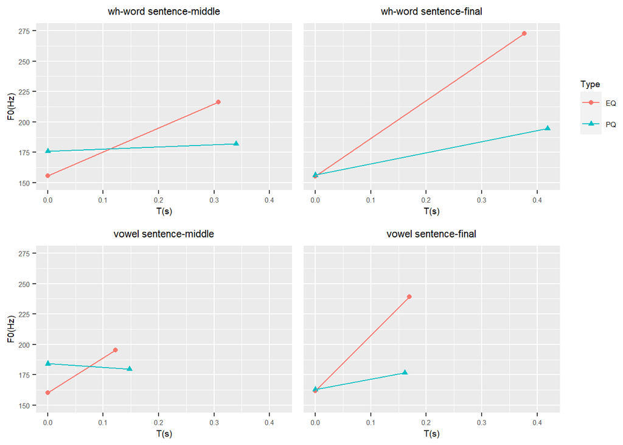

```r
# arrange the 4 plots made above
# plots have same scales and right columns have no y-axes
inter_graph = ggarrange(wh_mid_inter_graph +
            theme(legend.position = "none"),
          wh_end_inter_graph +
            theme(axis.text.y = element_blank(),
                  axis.ticks.y = element_blank(),
                  axis.title.y = element_blank(),
                  plot.margin = margin(l = 1)),
          vowel_mid_inter_graph +
            theme(legend.position = "none"),
          vowel_end_inter_graph +
            theme(axis.text.y = element_blank(),
                  axis.ticks.y = element_blank(),
                  axis.title.y = element_blank(),
                  plot.margin = margin(l = 1),
                  legend.position = "none"),
          nrow = 2)
```